# PiP-P2P Power Analysis

Author

Affiliation

Joshua F. Wiley

Monash University

Published

August 31, 2025

# 1 Setup

Load required packages.

```r
library(pwrss)
library(ggplot2)
library(ggpubr)
library(data.table)
library(scales)
```

We have three primary outcomes. To account for multiple comparisons we use a conservative $\alpha = .015 < \frac{\alpha = .05}{3}$.

We assume a standardised mean difference of $d = 0.5$.

```r
cond <- as.data.table(
    expand.grid(
        alpha = c(.015),
        power = c(.95),
        d = .5,
        r = c(.5, .55, .6, .65, .7),
        attrition = c(.15, .20, .25)
    )
)
```

Use this paper Ruscio, J. (2008). A probability-based measure of effect size: Robustness to base rates and other factors. Psychological Methods, 13(1), 19-30. doi:10.1037/1082-989x.13.1.19 to convert $d$ to $R^2$.

```r
cond[, r2 := ( d / sqrt(d^2 + 4) ) ^2] ## convert d to R^2
```

# 2 Calculate Power

Use a loop and calculate all power analyses. $k = 5$ because we assume five predictors in the regression models: three dummy codes to capture every combination of 2 x 2 strata, 1 for the outcome at baseline (continuous, controll variable), and 1 for the dummy code for the treatment condition. $m = 1$ because we are only interested in testing the treatment condition. The attrition rate is the proportion of participants that drop out of the study. We adjust by this so that we are viewing the total sample size needed.

for the $f^2$ effect size, we take the assumed do to $R^2$ conversion, and additionally subtract the variance in the outcome after intervention we expect to be accounted for by controlling for the outcome at baseline, that is:

$$f^2 = \frac{R^2_{from~d}}{1 - R^2_{from~d} - r^2_{baseline-post~correlation}}$$

```r
for (i in seq_len(nrow(cond))) {
  cond[i, N := ceiling(
    pwrss.f.reg(f2 = cond[i, r2] / (1 - cond[i, r2] - cond[i, r]^2),
      k = 5, m = 1, power = cond[i, power],
      alpha = cond[i, alpha])$n / (1 - cond[i, attrition]))]
}

cond[, r2 := NULL]
cond[, r := factor(r)]
cond[, alpha := factor(alpha)]
cond[, power := factor(power)]
```

# 3 Show Results

Make a graph of the results and save to PDF and PNG for use in publications.

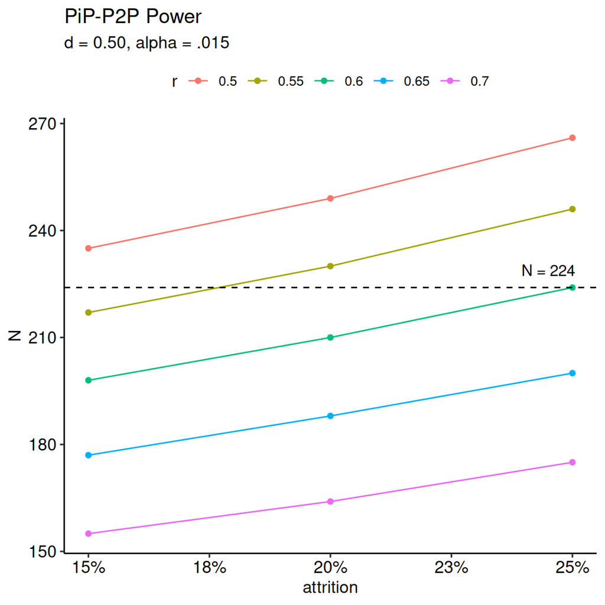

Power analysis for the regression model based on different assumptions. Results are adjusted for attrition.

```r
power <- ggplot(cond, aes(attrition, N, colour = r)) +
  geom_line() + geom_point() +
  annotate("text", x = .245, y = 224, label = "N = 224", vjust = -1) +
  scale_x_continuous(label = percent_format(accuracy = 1)) +
  geom_hline(yintercept = 224, linetype = "dashed") +
  theme_pubr() + ggtitle("PiP-P2P Power", subtitle = "d = 0.50, alpha = .015")

print(power)
```

```r
ggsave("power.pdf", plot = power, width = 6, height = 6)
ggsave("power.png", plot = power, width = 6, height = 6, dpi = 600)
```